← Back to Home | Download Notebook (.ipynb)

# How Neural Networks Learn to See: Building an Edge Detector from Scratch

*A hands-on guide to understanding how a single neuron detects patterns in images*

Have you ever wondered how neural networks can recognize faces, read handwriting, or detect objects in photos? It all starts with something surprisingly simple: **pattern matching**.

In this post, we'll build an edge detector from scratch to understand the fundamental operation at the heart of all neural networks. By the end, you'll have an intuitive grasp of:

- How a single neuron works (it's just multiplication and addition!)
- Why **weights** determine what patterns a neuron responds to
- How **ReLU activation** acts as a gate
- Why **bias** matters for controlling sensitivity

No prior deep learning knowledge required — just basic math intuition.

## The Big Picture: What Does a Neuron Actually Do?

A neuron in a neural network does three things:

1. **Multiply** each input by a learned weight
2. **Add** all the products together (plus a bias term)
3. **Apply an activation function** (we'll use ReLU)

Mathematically:

$$z = \sum_{i} x_i \cdot w_i + b = (x_1 \cdot w_1) + (x_2 \cdot w_2) + \ldots + (x_n \cdot w_n) + b$$

$$\text{output} = \text{ReLU}(z) = \max(0, z)$$

That's it! The magic is in *what values the weights take* — they determine what pattern the neuron responds to.

**Intuition:** Think of each input as an expert's opinion, and the weights as how much you trust each expert. A large positive weight means "this input is very important." A negative weight means "if this input is high, I'm *less* interested."

```python
def weighted_sum(inputs, weights, bias=0):
    """Compute the weighted sum: z = sum(x * w) + b"""
    return np.sum(inputs * weights) + bias

def relu(z):
    """ReLU activation: max(0, z)"""
    return np.maximum(0, z)

def neuron_output(inputs, weights, bias=0):
    """Complete neuron: weighted sum followed by ReLU"""
    z = weighted_sum(inputs, weights, bias)
    return relu(z), z
```

## What is ReLU and Why Do We Need It?

**ReLU** (Rectified Linear Unit) is the simplest activation function:

$$\text{ReLU}(z) = \max(0, z) = \begin{cases} z & \text{if } z > 0 \\ 0 & \text{if } z \leq 0 \end{cases}$$

It acts as a **gate**: positive signals pass through unchanged, negative signals get blocked.

**Why is this useful?** Without an activation function, stacking layers would be pointless — the whole network would collapse into a single linear transformation. ReLU introduces *non-linearity*, which allows the network to learn complex patterns.

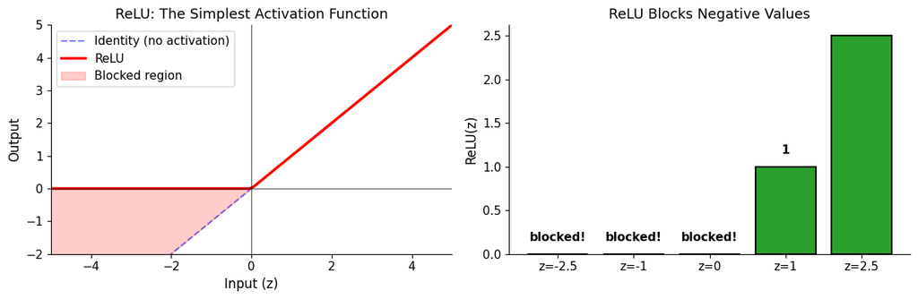

## Building an Edge Detector

Now let's see how a neuron can detect a specific pattern: a **vertical edge**.

Imagine a tiny 5×5 grayscale image (25 pixels). A neuron connected to this image has:

- **25 inputs** (one per pixel, values 0–1 where 0=black, 1=white)
- **25 weights** (one per connection)
- **1 output** (after weighted sum + ReLU)

### Designing the Weights

To detect a vertical edge (dark on left, bright on right), we set:

- **Negative weights (-1)** on the left columns → "I want darkness here"
- **Positive weights (+1)** on the right columns → "I want brightness here"
- **Zero weights (0)** in the middle → "I don't care about this region"

When an image with this exact pattern arrives, the positive and negative contributions reinforce each other, giving a high score. When the pattern doesn't match, contributions cancel out or go negative.

```python
# The key insight: these weights define WHAT the neuron looks for
edge_weights = np.array([
    [-1, -1, 0, +1, +1],
    [-1, -1, 0, +1, +1],
    [-1, -1, 0, +1, +1],
    [-1, -1, 0, +1, +1],
    [-1, -1, 0, +1, +1]
], dtype=float)
```

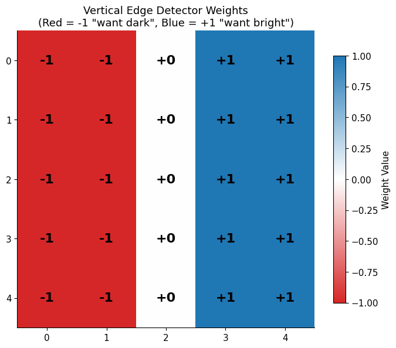

## Testing Our Detector on Different Images

Let's create several test images to see how our detector responds:

| Image | Description | Expected Response |
| --- | --- | --- |
| Perfect Edge | Dark left, bright right | **Strong** (pattern matches!) |
| Shifted Edge | Edge in wrong position | **Reduced** (partial match) |
| Uniform Gray | No edge at all | **Zero** (no contrast) |
| Inverted Edge | Bright left, dark right | **Blocked** (opposite of what we want) |
| Horizontal Edge | Edge rotates 90° | **Weak** (wrong orientation) |

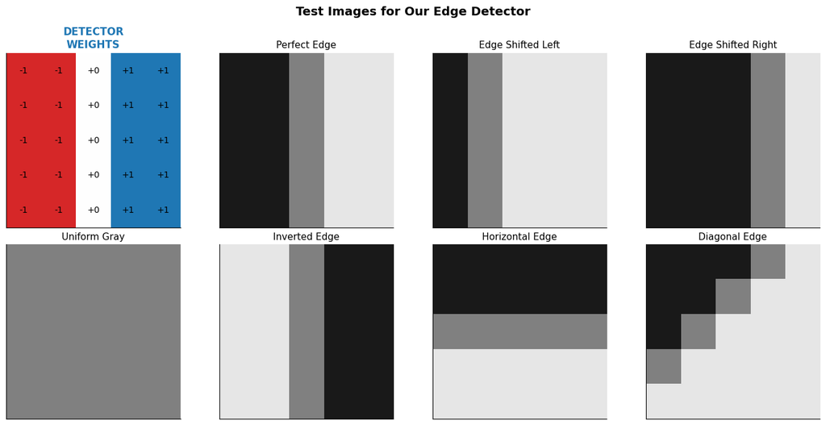

## Computing the Neuron's Response

For each image, we compute:

$$z = \sum_{i,j} \text{image}[i,j] \times \text{weight}[i,j] + b$$

$$\text{output} = \max(0, z)$$

> **Note:** We're setting **bias $b = 0$** for now to keep things simple. This lets us focus purely on how the weight pattern matches the input. We'll explore bias later!

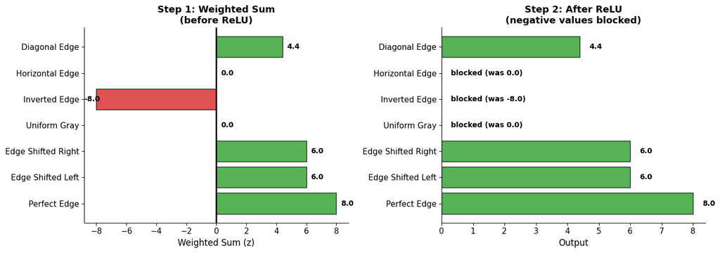

## Visualizing the Math: Step by Step

Let's look inside the calculation to see exactly how the score emerges from element-wise multiplication.

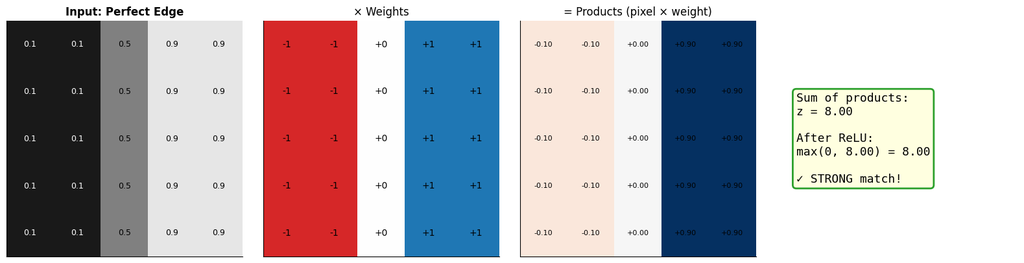

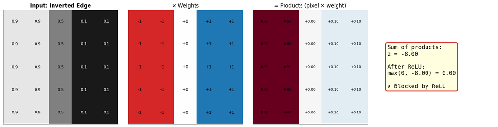

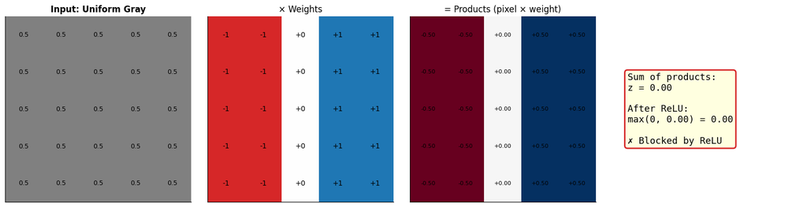

## The Flattened View: It's Just a Dot Product!

The 5×5 matrix representation is convenient for visualization, but the actual computation is simply a **dot product** of two 25-element vectors:

$$z = \vec{x} \cdot \vec{w} = x_0 w_0 + x_1 w_1 + \ldots + x_{24} w_{24}$$

Let's see what this looks like when we "unroll" the matrices into strips:

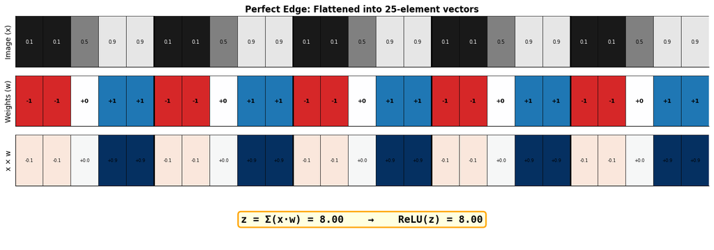

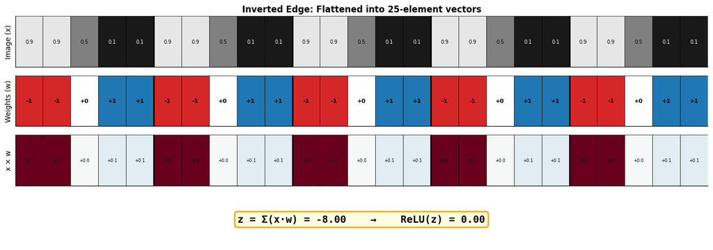

## Key Insight: Alignment Determines Response

The neuron's output depends entirely on **how well the input aligns with the weight pattern**:

[output not shown]

## The Role of Bias: Adjusting Sensitivity

So far we've set bias $b = 0$. But what does bias actually do?

- **Weights** control *what pattern* the neuron responds to
- **Bias** controls *how easily* the neuron activates — it shifts the threshold

$$z = \sum(x \cdot w) + b$$

- **Positive bias** → Easier to activate (even weak matches pass through)
- **Negative bias** → Harder to activate (only strong matches pass through)

Think of bias as the neuron's "baseline mood" — a positive bias means it's eager to fire, while a negative bias means it needs more convincing.

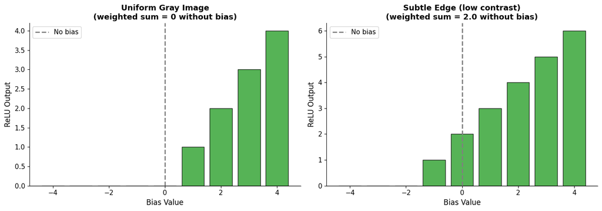

Notice how:

- With **negative bias**, even the subtle edge gets blocked
- With **positive bias**, weak signals (or even no signal!) can activate the neuron

In a trained network, each neuron learns its own optimal bias along with its weights.

## Different Detectors for Different Patterns

Our vertical edge detector is just one example. By changing the weights, we can detect completely different patterns:

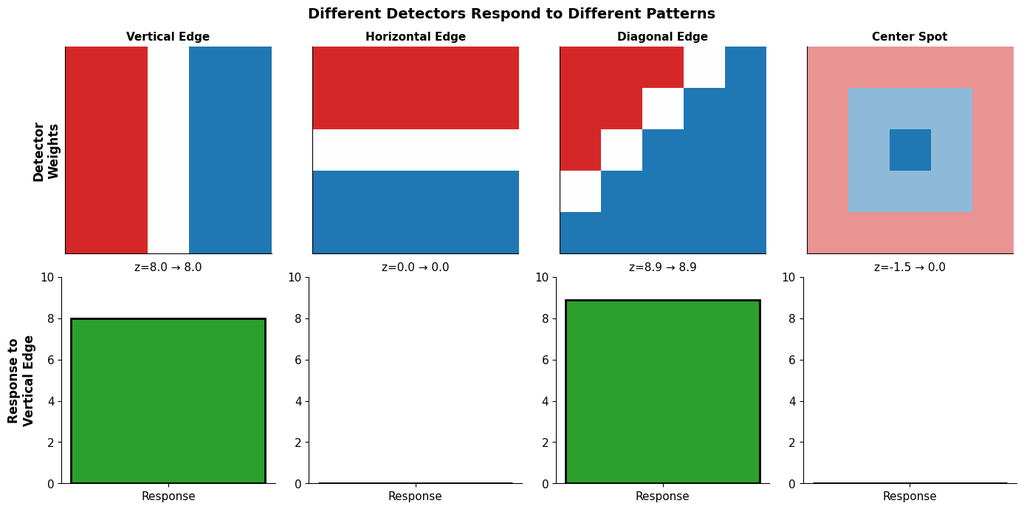

## From Single Neurons to Deep Networks

A real neural network has thousands or millions of neurons arranged in layers:

- **Layer 1** neurons learn simple patterns (edges, colors, textures)
- **Layer 2** neurons combine Layer 1 outputs to detect shapes (curves, corners)
- **Layer 3** neurons combine shapes into parts (eyes, wheels, windows)
- **Output layer** combines parts into final classifications (cat, car, digit)

This hierarchy — from simple to complex — is why deep learning works so well. And it all starts with the simple pattern matching we've explored here!

**The key insight:** We don't design these weights by hand. During training, the network automatically discovers what patterns are useful for the task. Backpropagation adjusts each weight to reduce errors, and useful detectors emerge naturally.

## Try It Yourself!

Modify the image below and re-run to see how the detector responds:

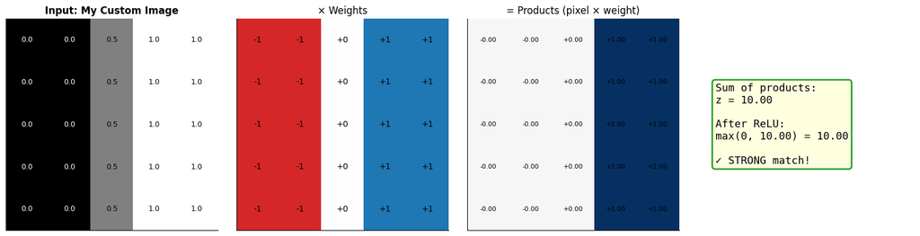

## Summary

We've built an edge detector from scratch and discovered the core principles that power all neural networks:

| Concept | What It Does | Analogy |
| --- | --- | --- |
| **Weights** | Define what pattern the neuron detects | A template to match against |
| **Weighted Sum** | Measure how well input matches the pattern | A similarity score |
| **Bias** | Shift the activation threshold | The neuron's "eagerness" to fire |
| **ReLU** | Block negative responses | A gate that only passes matches |

### The Big Ideas

1. **A neuron is a pattern matcher.** High output = good match, zero output = poor match.
2. **Weights encode knowledge.** The specific values determine what the neuron "looks for."
3. **Learning = finding good weights.** Training adjusts weights until useful patterns emerge.
4. **Depth creates hierarchy.** Simple detectors combine into complex recognizers.

This simple mechanism — multiply, sum, activate — repeated billions of times with learned weights, is how neural networks learn to see, read, translate, and even generate art.

*Now you understand the atom of deep learning. Everything else is scale and clever architecture!*